# Miscellaneous RTMB Coding

## Passing Data to RTMB (Option 1)

- Only the parameters argument as a list can be passed to `MakeADFun`
- One option is to write a wrapper function
- By using a wrapper function, we force the data into the objective function’s parent environment

```r
library(RTMB)

param <- list(logsigma = 0, alpha = 0, logbeta = 0)

objective_function <- \(pars, data){
  getAll(pars, data)
  mu <- alpha - exp(logbeta)*spawners
  sigma <- exp(logsigma)

  nll <- -sum(dnorm(logRS, mu, sigma, log = TRUE))
  return(nll)
}

join_fun <- function(f, data) function(pars) f(pars, data)
stellako <- sox %>% filter(PopName == "Stellako")
obj_stellako <- MakeADFun(join_fun(objective_function, stellako), param, silent = TRUE)
fit_stellako <- nlminb(obj_stellako$par, obj_stellako$fn, obj_stellako$gr)

latestuart <- sox %>% filter(PopName == "Late Stuart")
obj_latestuart <- MakeADFun(join_fun(objective_function, latestuart), param, silent = TRUE)
fit_latestuart <- nlminb(obj_latestuart$par, obj_latestuart$fn, obj_latestuart$gr)
```

## Passing Data to RTMB (Option 2)

- Pass the data to the function environment
- Helpful for package development

```r
objective_function <- \(pars){
  getAll(pars, data)
  mu <- alpha - exp(logbeta)*spawners
  sigma <- exp(logsigma)

  nll <- -sum(dnorm(logRS, mu, sigma, log = TRUE))
  return(nll)
}

make_adfun <- function(pars, data){
  ## The entire function's environment
  # environment(objective_function) <- environment()

  ## Just data:
  data_env <- local({data <- data; environment()})
  environment(objective_function) <- data_env

  obj <- MakeADFun(objective_function, pars, silent = TRUE)   ## the starting values passed in
  obj
}

nadina <- sox %>% filter(PopName == "Nadina")
obj_nadina <- make_adfun(param, nadina)
fit_nadina <- nlminb(obj_nadina$par, obj_nadina$fn, obj_nadina$gr)
```

## ADcontext

- Can write code that will only execute when the function is called in an R context
- Use `ad_context()` to check if the function is being taped `TRUE`or not.
- Can use it to simulate within your model code, which when calling `$report()` will execute in R
- Super useful for transformations when there could create bias in the mean
- `ad_context()` is internal to RTMB (hence the `:::`), so it can change between versions

```r
data(cars)

pred_func <- function(pars) {
  getAll(pars, cars, warn = FALSE)
  mu <- beta[1] + beta[2] * speed
  sigma <- exp(logsigma)

  dist %~% dnorm(mu, sd = sigma)

  ## Prediction interval via simulation, at the parameter values report() is given
  if (!RTMB:::ad_context()) {
    sim_matrix <- replicate(10000, rnorm(length(mu), mean = mu, sd = sigma))
    pred_intervals <- apply(sim_matrix, 1, quantile, probs = c(0.025, 0.975))
    REPORT(mu)
    REPORT(pred_intervals)
  }
}

obj <- MakeADFun(pred_func, list(beta = c(0,0), logsigma = log(sd(cars$dist))), silent = TRUE)
fit <- nlminb(obj$par, obj$fn, obj$gr)
set.seed(1)
intervals <- t(obj$report(fit$par)$pred_intervals)

## Mean width of the interval, against lm()
pred_lm <- predict(lm(dist ~ speed, data = cars), newdata = cars, interval = "prediction")
round(c(simulated = mean(intervals[,2] - intervals[,1]), lm = mean(pred_lm[,"upr"] - pred_lm[,"lwr"])), 1)
```

```
simulated        lm
     59.1      63.1
```

- This is a “plug-in” interval: it treats the estimates as known, so it is a little too narrow.
- The **Predictions** slide later adds the uncertainty in the estimates.

## Fixing Overload Errors

- You might find a bug of “Invalid argument to ‘advector’ (lost class attribute?)”
- A quick solution to this is to make sure any functions written in R have an AD overload operator added
- Required for all functions within a package!

```r
myfunc <- \(par){
"c" <- ADoverload("c")
"diag<-" <- ADoverload("diag<-")
# The rest of the function...
}
```

## Things with no gradient

- A uniform *prior* needs no density at all: it is a constant. Keep the parameter in range with a transformation (e.g. `plogis`) or with bounds in `nlminb`.
- A uniform model for *data* with estimated end points will not work: the likelihood jumps at the end points.
- No while loops if the number of iterations depends on parameters
- No if statements that depend on parameter values
- Dimension and number of operations must be set
- There are *tricks* to retape each iteration, or overload AD in some cases

## Forcing AD Overload

- `ADoverload("if")` lets a tape branch on the value of a parameter.
- RTMB lists it as experimental, and the condition must be a single value (not a vector).

```r
f <- function(x) {
  "if" <- ADoverload("if")
  if (x > 0) {
    3*x^2
  } else {
    x + x^2
  }
}

F <- MakeTape(f, 1)
F(2)
```

```
[1] 12
```

```r
F(-2)
```

```
[1] 2
```

```r
F$jacobian(2)
```

```
     [,1]
[1,]   12
```

```r
F$jacobian(-100)
```

```
     [,1]
[1,] -199
```

```r
## This isn't going to work: the number of terms in each sum depends on x
f <- function(x) {
  "if" <- ADoverload("if")
  if(x > 5){
    sum(dpois((x-5):(x+5), 5))
  }else{
    sum(dpois(0:x, 3))
  }
}
```

## Probabilistic Syntax

- Other ways to code likelihood
- We can declare data using `%~%`
- Don’t have to explicitly write `log = TRUE`
- Don’t need to declare we are returning anything
- More intuitive for many people
- Use one style per function. With `%~%` the function returns its own running total, so a `return(nll)` built by hand is ignored and the terms in it are silently lost.

```r
x <- rnorm(100, 5, 2)

pars <- list(logsigma = 0, mu = 0)

negll <- \(pars){
  getAll(pars)
  sigma <- exp(logsigma)
  x %~% dnorm(mu, sigma)
}

obj <- MakeADFun(negll, pars)
# obj$fn()
```

## Newton Solver

- RTMB has a built in Newton solver to do optimization within a tape
- Used for Laplace approximation

```r
x <- rnorm(100, 0.25, 0.1)
F <- MakeTape(\(theta){-sum(dnorm(x, theta[1], exp(theta[2]), log = TRUE))}, c(0,0))
opt <- F$newton(1:2)
opt(numeric(0))
```

```
[1]  0.2408494 -2.2873750
```

```r
## Finds the MLE of mean given standard deviation
optmu <- F$newton(1)
optmu(3)
```

```
[1] 0.2408494
```

```r
## Finds the MLE of standard deviation given mean
optmu <- F$newton(2)
exp(optmu(0.1))
```

```
[1] 0.1736301
```

## Predictions

- Let’s use RTMB to get a prediction standard error
- Compare with `lm` in R using cars data
- Augment data and predict with `ADREPORT`
- Confidence interval: uncertainty in the mean (`se`). Prediction interval: add the spread of a new observation, `sqrt(se^2 + sigma^2)`.

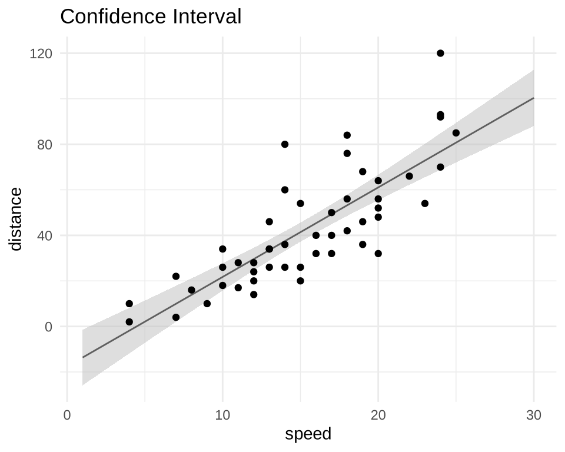

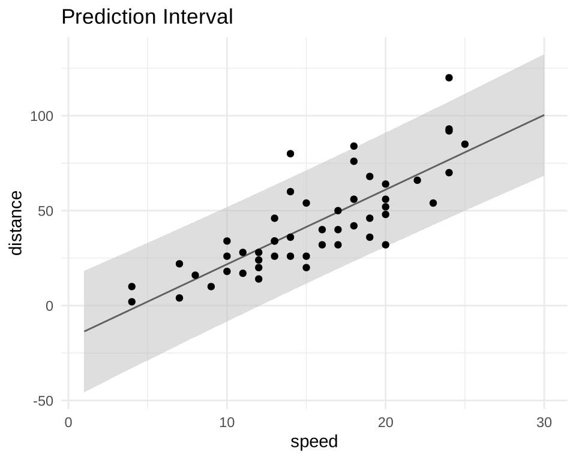

```r
data(cars)

pred_func <- \(pars){
  getAll(pars, data, warn = FALSE)
  sigma <- exp(logsigma)
  mu  <- beta[1] + beta[2]*speed
  dist <- OBS(dist)
  mis <- is.na(dist)
  dist[!mis] %~% dnorm(mu[!mis], sd=sigma)
  ADREPORT(mu[mis])
}

## Add augmented data
newdata <- data.frame(speed = 1:30, dist = NA)
data <- rbind(cars, newdata)
obj <- MakeADFun(pred_func, list(beta = c(0,0), logsigma = 0), silent = TRUE)
fit <- nlminb(obj$par, obj$fn, obj$gr)
sdr <- sdreport(obj)
pred <- cbind(newdata, summary(sdr, select = "report"))
names(pred) <- c("speed", "dist", "est", "se")

ggplot(data = pred, aes(x = speed, y = est)) +
  geom_line() + theme_minimal() +
  geom_ribbon(aes(x = speed, ymin = est - 1.96*se, ymax = est + 1.96*se), fill = 'grey', alpha = 0.5) +
  geom_point(data = cars, aes(x = speed, y = dist)) +
  ylab("distance") +
  ggtitle("Confidence Interval")
## Prediction interval
sd_est <- exp(fit$par[3])
ggplot(data = pred, aes(x = speed, y = est)) +
  geom_line() + theme_minimal() +
  geom_ribbon(aes(x = speed, ymin = est - 1.96*sqrt(se^2 + sd_est^2), ymax = est + 1.96*sqrt(se^2 + sd_est^2)), fill = 'grey', alpha = 0.5) +
  geom_point(data = cars, aes(x = speed, y = dist)) +
  ylab("distance") +
  ggtitle("Prediction Interval")
```

## TMB STAN

- We can pass the object from `RTMB` to `STAN` using `tmbstan`
- Just need to make sure your distributions are correct for the prior that you want
- Either explicitly tell `tmbstan` the bounds of your variables, or use Jacobians to transform the prior distributions and pass things on the transformed scale.
- Give every parameter a prior, and check the sampler’s diagnostics (R-hat, effective sample size, divergences) before using the draws.
- Newer samplers that take an RTMB object: `SparseNUTS` and `StanEstimators` (neither is on CRAN yet).

```r
library(tmbstan)

data(cars)

## Option 1: transformed parameters + Jacobians
negll <- \(pars){
  getAll(pars, cars, warn = FALSE)
  sigma <- exp(logsigma)
  REPORT(sigma)
  mu  <- beta[1] + beta[2]*speed
  nll <- -sum(dnorm(beta, 0, 5, log = TRUE)) ## prior
  nll <- nll - dgamma(sigma, 1, 1, log = TRUE) - logsigma ## prior
  nll <- nll - sum(dnorm(dist, mu, sd=sigma, log = TRUE))
  nll
}

obj <- MakeADFun(negll, list(beta = c(0,0), logsigma = 0))
fit <- tmbstan(obj)
post_sigma <- exp(as.matrix(fit)[,"logsigma"])

## Option 2: parameters on their natural scale + bounds
negll2 <- \(pars){
  getAll(pars, cars, warn = FALSE)
  mu  <- beta[1] + beta[2]*speed
  nll <- -sum(dnorm(beta, 0, 5, log = TRUE)) ## prior
  nll <- nll - dgamma(sigma, 1, 1, log = TRUE) ## prior
  nll <- nll - sum(dnorm(dist, mu, sd=sigma, log = TRUE))
  nll
}

obj2 <- MakeADFun(negll2, list(beta = c(0,0), sigma = 2))
fit2 <- tmbstan(obj2, lower = c(-Inf, -Inf, 0), upper = c(Inf, Inf, Inf))
post_sigma2 <- as.matrix(fit2)[,"sigma"]

plot(density(post_sigma), main = "posterior sigma")
lines(density(post_sigma2), col = 'red')
```

## TMB STAN Processing

- To process predicted values we can use `REPORT`

```r
post <- as.matrix(fit)
post <- cbind(post, sigma = 0)
for( i in 1:nrow(post) ) post[i, "sigma"] <- obj$report(post[i,1:3])$sigma
```